# Examples of masking data

Ana Martinovici

Last compiled on 2026-06-09 at 13:51:06

This file provides examples of how to work with data that is not shared in the repo, and that can not be shared as-is with others.

```r
library("tidyverse")
# data is read from an external location (i.e., not in the repo)
path_to_data <- here::here(Sys.getenv("PATH_TO_DROPBOX"),
                           "Teaching",
                           "RSM",
                           "MM_programme",
                           "DFCP",
                           "DFCP_2025-2026",
                           "Spotify_data")
```

I have placed a data access request for my Spotify data and received in return 3 archives. After unzipping the archives, these are the files within each folder:

```r
printtree::print_rtree(path = here::here(path_to_data))
```

```
## Spotify_data/
## |-- account_data/
## |   `-- Spotify Account Data/
## |       |-- AgentGateway.json
## |       |-- DuoNewFamily.json
## |       |-- Follow.json
## |       |-- Identifiers.json
## |       |-- Marquee.json
## |       |-- Payments.json
## |       |-- Playlist1.json
## |       |-- Read_Me_First.pdf
## |       |-- SearchQueries.json
## |       |-- StreamingHistory_audiobook_0.json
## |       |-- StreamingHistory_music_0.json
## |       |-- StreamingHistory_podcast_0.json
## |       |-- UserAttributes.json
## |       |-- Wrapped2025.json
## |       |-- YourLibrary.json
## |       `-- YourSoundCapsule.json
## |-- extended_streaming_history/
## |   `-- Spotify Extended Streaming History/
## |       |-- ReadMeFirst_ExtendedStreamingHistory.pdf
## |       |-- Streaming_History_Audio_2016.json
## |       |-- Streaming_History_Audio_2017.json
## |       |-- Streaming_History_Audio_2018.json
## |       |-- Streaming_History_Audio_2019.json
## |       |-- Streaming_History_Audio_2020.json
## |       |-- Streaming_History_Audio_2021.json
## |       |-- Streaming_History_Audio_2022.json
## |       |-- Streaming_History_Audio_2023.json
## |       |-- Streaming_History_Audio_2024.json
## |       |-- Streaming_History_Audio_2025.json
## |       |-- Streaming_History_Audio_2026.json
## |       |-- Streaming_History_Video_2024.json
## |       `-- Streaming_History_Video_2025.json
## |-- technical_log/
## |   `-- Spotify Technical Log Information/
## |       |-- AccessoryStateEvent.json
## |       |-- AccountMutated.json
## |       |-- AccountPagesActivity.json
```

[output cut: 122 more lines]

```
## |       |-- StutterPrediction.json
## |       |-- SystemVolumeControl.json
## |       |-- TrackNotPlayed.json
## |       |-- TransactionalEmailerEmailEvent.json
## |       |-- UserAuthenticationSuccess.json
## |       |-- WasapiAudioDriverInfo.json
## |       |-- WhereToPlayClientRecommendationNotDisplayed.json
## |       |-- WindowSize.json
## |       |-- WwwAnalytics.json
## |       `-- WwwExperiments.json
## |-- account_data.zip
## |-- extended_streaming_history.zip
## `-- technical_log.zip
##
## 6 directories, 168 files
```

The sheer number of files and the amount of information within each of them is overwhelming. For each of the 3 archives / groups of data files, there is ReadMe file that provides additional information. These ReadMe files are pdfs and have pages upon pages of tables with `item name` and `item description`. It is possible to go through all of those pages and figure out what each file and variable name stores. However, it is not feasible to do so within a reasonable time, by an average user. For example, the Granular Description of Technical Log Files is about 500 pages long. Data dictionaries would be much more useful if provided in a format that can more easily be processed and stored together with the data it describes.

These files contain personal data and information that I want to keep private.

For example, `technical_log\Spotify Technical Log Information\recipients.json` contains information about who might have received my data. See screenshot from the ReadMe file:

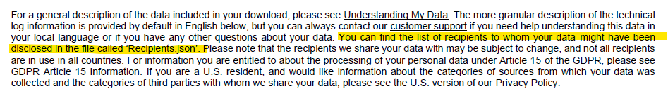

```r
knitr::include_graphics(path = here::here("data_outside_repo", "readme_tech_1.png"),
                        rel_path = FALSE,
                        dpi = 10)
```

However, I can mask some of the data and share the masked version. In doing so, I have in mind the principle of data minimization. That is, I will try to share as little data as necessary for my specific goal. For example, if I want to make a statement about how many companies have received my data, I can mask all company names and share that. The masked data can still be used to count the number of companies - their specific names are not relevant.

```r
orig_recipients <- jsonlite::fromJSON(txt = here::here(path_to_data,
                                                       "technical_log",
                                                       "Spotify Technical Log Information",
                                                       "recipients.json"),
                                      simplifyDataFrame = FALSE)
```

This reads in a list with one item:

```r
names(orig_recipients)
```

```
## [1] "recipients"
```

Recipients are split in two types:

```r
purrr::map_chr(orig_recipients[["recipients"]], "name")
```

```
## [1] "Other Companies"         "Spotify Group Companies"
```

# 1 Example 1

If I want to report the total number of recipients, without the split by type, then I can put the members info in a `df` and then mask their names:

```r
df_orig <- orig_recipients[["recipients"]] %>%
    map_dfr(\(x) {
        tibble(
            members = x[["members"]]
        )
    })
```

I will first check how many unique values there are:

```r
df_orig %>%
    distinct(members) %>%
    nrow()
```

```
## [1] 106
```

Good, as many as the number of observations. I can replace the values of the `members` variable with a value that clearly communicates this is masked information.

```r
df_processed <- df_orig %>%
    mutate(masked_members = paste0("Masked_Name", row_number())) %>%
    select(-members)
```

Now, `df_processed` can be saved in the repo and shared with others.

# 2 Example 2

If I want to report the number of members by type, then I need to keep that information in.

```r
df_orig <- orig_recipients[["recipients"]] %>%
    map_dfr(\(x) {
        tibble(
            name = x[["name"]],
            members = x[["members"]]
        )
    })

df_processed <- df_orig %>%
    group_by(name) %>%
    mutate(masked_members = paste0("Masked_Name", row_number())) %>%
    ungroup() %>%
    select(-members)
```

Now, `df_processed` can be saved in the repo and shared with others.

```r
save(df_processed,
     file = here::here("data_outside_repo",
                      "masked_members.RData"))
```